# Home Work Assignment - 01

Critical Thinking Group 5

```r
library(ggplot2)
library(MASS)
library(knitr)
library(xtable)
library(dplyr)
library(psych)
library(stringr)

moneyballvars <- read.csv("https://raw.githubusercontent.com/kishkp/data621-ctg5/master/HW1/moneyballvars.csv")

moneyballvars <- moneyballvars[moneyballvars[,1]!="INDEX",]

moneyball<- read.csv("https://raw.githubusercontent.com/kishkp/data621-ctg5/master/HW1/moneyball-training-data.csv")

moneyball2<- select(moneyball, -(INDEX))
```

# Data Exploration

In this section we will explore how the data looks like. The goal of data exploration is to look at summaries / descriptives for each variable, shape of the distribution, identify variables of interest, decide on how to treat missing values and outliers.

First lets look at the variables.

```r
moneyballvars <- read.csv("https://raw.githubusercontent.com/kishkp/data621-ctg5/master/HW1/moneyballvars.csv")

kable(moneyballvars)
```

| VARIABLE_NAME | DEFINITION | THEORETICAL_EFFECT |
| --- | --- | --- |
| INDEX | Identification Variable (do not use) | None |
| TARGET_WINS | Number of wins | Target |
| TEAM_BATTING_H | Base Hits by batters (1B,2B,3B,HR) | Positive Impact on Wins |
| TEAM_BATTING_2B | Doubles by batters (2B) | Positive Impact on Wins |
| TEAM_BATTING_3B | Triples by batters (3B) | Positive Impact on Wins |
| TEAM_BATTING_HR | Homeruns by batters (4B) | Positive Impact on Wins |
| TEAM_BATTING_BB | Walks by batters | Positive Impact on Wins |
| TEAM_BATTING_HBP | Batters hit by pitch (get a free base) | Positive Impact on Wins |
| TEAM_BATTING_SO | Strikeouts by batters | Negative Impact on Wins |
| TEAM_BASERUN_SB | Stolen bases | Positive Impact on Wins |
| TEAM_BASERUN_CS | Caught stealing | Negative Impact on Wins |
| TEAM_FIELDING_E | Errors | Negative Impact on Wins |
| TEAM_FIELDING_DP | Double Plays | Positive Impact on Wins |
| TEAM_PITCHING_BB | Walks allowed | Negative Impact on Wins |
| TEAM_PITCHING_H | Hits allowed | Negative Impact on Wins |
| TEAM_PITCHING_HR | Homeruns allowed | Negative Impact on Wins |
| TEAM_PITCHING_SO | Strikeouts by pitchers | Positive Impact on Wins |

We notice that all variables are numeric. The variable names seem to follow certain naming pattern to highlight certain arithmetic relationships. In other words, we can compute the number of ‘1B’ hits by taking the difference between overall hits and ‘2B’, ‘3B’, ‘HR’. Although such naming and construct is not recommended in normalized database design ( as it violates third normal form), it is very frequent practice in the data analytics.

Our predictor input is made of 15 variables. And our dependent variable is one variable called TARGET_WINS.

Next we start with a summary of the variables and see what we can infer from the same. The goal is to look at measures of central tendancy and dispersion to see how the variables are currently placed in their structure.

## Summary / Descriptives / Correlation

```r
ds_stats <- psych::describe(moneyball2, skew = FALSE, na.rm = TRUE)[c(3:6)]
ds_stats <- cbind(VARIABLE_NAME = rownames(ds_stats), ds_stats)
#rownames(ds_stats) <- NULL

Variable<- rownames(ds_stats)

fun <- function(x) sum(!complete.cases(x))
Missing <- sapply(moneyball2[Variable], FUN = fun)

#ds_stats <- cbind(ds_stats, Missing)


# fun <- function(x) mean(x, na.rm=T)
# Mean <- sapply(moneyball2[Variable], FUN = fun)

fun <- function(x, y) cor(y, x, use = "na.or.complete")
Correlation <- sapply(moneyball2[Variable], FUN = fun, y=moneyball2$TARGET_WINS)

ds_stats <- data.frame(cbind(ds_stats, Missing, Correlation))
ds_stats <- left_join(ds_stats, moneyballvars, by="VARIABLE_NAME")
kable(ds_stats)
```

| VARIABLE_NAME | mean | sd | median | trimmed | Missing | Correlation | DEFINITION | THEORETICAL_EFFECT |
| --- | --- | --- | --- | --- | --- | --- | --- | --- |
| TARGET_WINS | 80.79086 | 15.75215 | 82.0 | 81.31229 | 0 | 1.0000000 | Number of wins | Target |
| TEAM_BATTING_H | 1469.26977 | 144.59120 | 1454.0 | 1459.04116 | 0 | 0.3887675 | Base Hits by batters (1B,2B,3B,HR) | Positive Impact on Wins |
| TEAM_BATTING_2B | 241.24692 | 46.80141 | 238.0 | 240.39627 | 0 | 0.2891036 | Doubles by batters (2B) | Positive Impact on Wins |
| TEAM_BATTING_3B | 55.25000 | 27.93856 | 47.0 | 52.17563 | 0 | 0.1426084 | Triples by batters (3B) | Positive Impact on Wins |
| TEAM_BATTING_HR | 99.61204 | 60.54687 | 102.0 | 97.38529 | 0 | 0.1761532 | Homeruns by batters (4B) | Positive Impact on Wins |
| TEAM_BATTING_BB | 501.55888 | 122.67086 | 512.0 | 512.18331 | 0 | 0.2325599 | Walks by batters | Positive Impact on Wins |
| TEAM_BATTING_SO | 735.60534 | 248.52642 | 750.0 | 742.31322 | 102 | -0.0317507 | Strikeouts by batters | Negative Impact on Wins |
| TEAM_BASERUN_SB | 124.76177 | 87.79117 | 101.0 | 110.81188 | 131 | 0.1351389 | Stolen bases | Positive Impact on Wins |
| TEAM_BASERUN_CS | 52.80386 | 22.95634 | 49.0 | 50.35963 | 772 | 0.0224041 | Caught stealing | Negative Impact on Wins |
| TEAM_BATTING_HBP | 59.35602 | 12.96712 | 58.0 | 58.86275 | 2085 | 0.0735042 | Batters hit by pitch (get a free base) | Positive Impact on Wins |
| TEAM_PITCHING_H | 1779.21046 | 1406.84293 | 1518.0 | 1555.89517 | 0 | -0.1099371 | Hits allowed | Negative Impact on Wins |
| TEAM_PITCHING_HR | 105.69859 | 61.29875 | 107.0 | 103.15697 | 0 | 0.1890137 | Homeruns allowed | Negative Impact on Wins |
| TEAM_PITCHING_BB | 553.00791 | 166.35736 | 536.5 | 542.62459 | 0 | 0.1241745 | Walks allowed | Negative Impact on Wins |
| TEAM_PITCHING_SO | 817.73045 | 553.08503 | 813.5 | 796.93391 | 102 | -0.0784361 | Strikeouts by pitchers | Positive Impact on Wins |
| TEAM_FIELDING_E | 246.48067 | 227.77097 | 159.0 | 193.43798 | 0 | -0.1764848 | Errors | Negative Impact on Wins |
| TEAM_FIELDING_DP | 146.38794 | 26.22639 | 149.0 | 147.57789 | 286 | -0.0348506 | Double Plays | Positive Impact on Wins |

Based on the table for the variables listed above, there are some things that stand out:

1. Some of the variables like TEAM_PITCHING_H, TEAM_PITCHING_SO and TEAM_FIELDING_E seem to have outliers which is evident from the mean, median and trimmed mean values.

2. TEAM_BATTING_HBP and TEAM_BASERUN_CS seems to be missing a lot of values which casts doubt on its usefulness as a predictor. Maybe a flag for presense or absense of TEAM_BATTING_HBP and TEAM_BASERUN_CS might be a better predictor. Also given the fact that there is low correlation, we decided to exclude these 2 variables from any missing value or outlier treatment.

3. Most of the variables seem to indicate a positive / negative correlation in line with the theoretical effect. However, the following stand out as they show a correlation opposite to the theoretical impact: TEAM_BASERUN_CS, TEAM_PITCHING_HR, TEAM_PITCHING_BB, TEAM_PITCHING_SO and TEAM_FIELDING_DP. Lets evaluate these variables further once we fix any missing values or outliers.

4. We will impute the missing values in TEAM_BATTING_SO, FIELDING_DP, BASERUN_SB and TEAM_PITCHING_SO since it has lesser missing values even though there is low correlation. So we will create new variables that will have the respective missing values handled.

## Distribution and Correlation

In this section we look at boxplots to determine the outliers in variables and decide on whether to act on the outliers.

Lets do some univariate analysis. We will look at the Histogram and Boxplot for each variable to detect outliers if any and treat it accordingly.

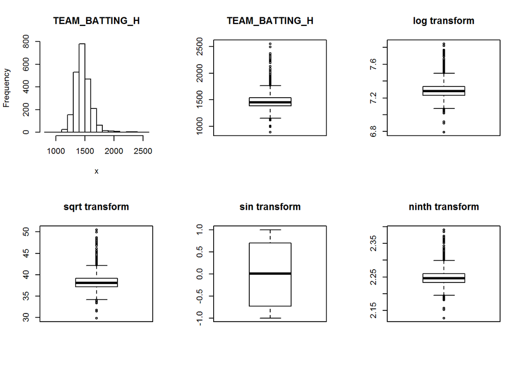

```r
show_charts <- function(x, ...) {

    par(mfrow=c(2,3))

    xlabel <- unlist(str_split(deparse(substitute(x)), pattern = "\\$"))[2]
#    ylabel <- unlist(str_split(deparse(substitute(y)), pattern = "\\$"))[2]

    hist(x,main=xlabel)
    boxplot(x,main=xlabel)

    y<-log(x)
    boxplot(y,main='log transform')
    y<-sqrt(x)
    boxplot(y,main='sqrt transform')
    y<-sin(x)
    boxplot(y,main='sin transform')
    y<-(x)^(1/9)
    boxplot(y,main='ninth transform')
}



#show_charts(moneyball2$TEAM_BATTING_H,moneyball2$TARGET_WINS)


show_charts(moneyball2$TEAM_BATTING_H)
```

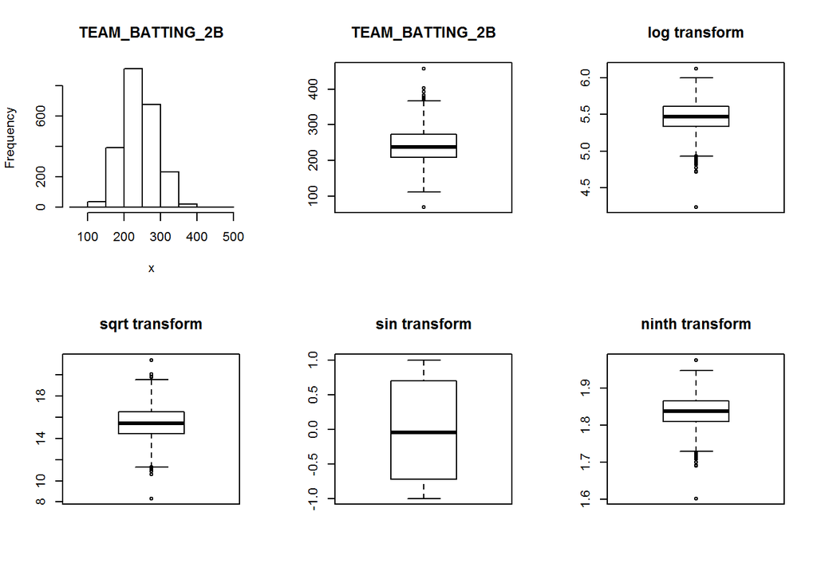

```r
show_charts(moneyball2$TEAM_BATTING_2B)
```

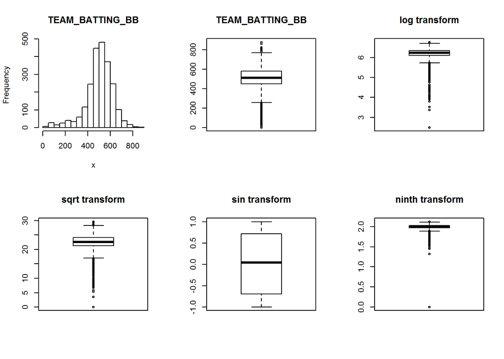

```r
show_charts(moneyball2$TEAM_BATTING_BB)
```

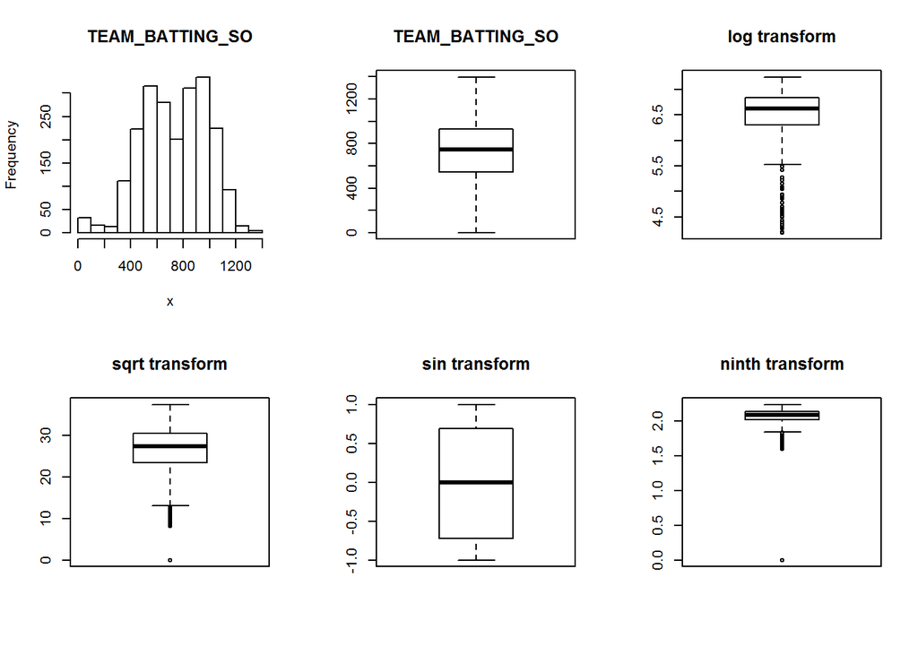

```r
show_charts(moneyball2$TEAM_BATTING_SO)
```

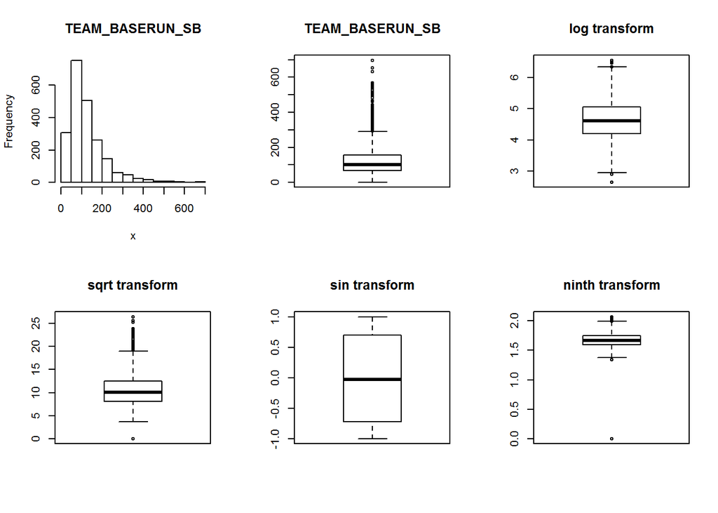

```r
show_charts(moneyball2$TEAM_BASERUN_SB)
```

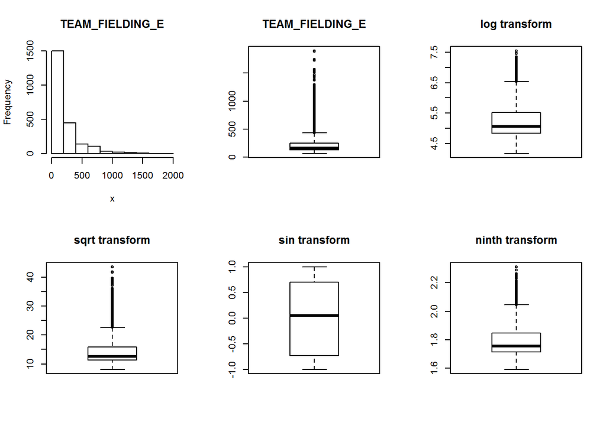

```r
show_charts(moneyball2$TEAM_FIELDING_E)
```

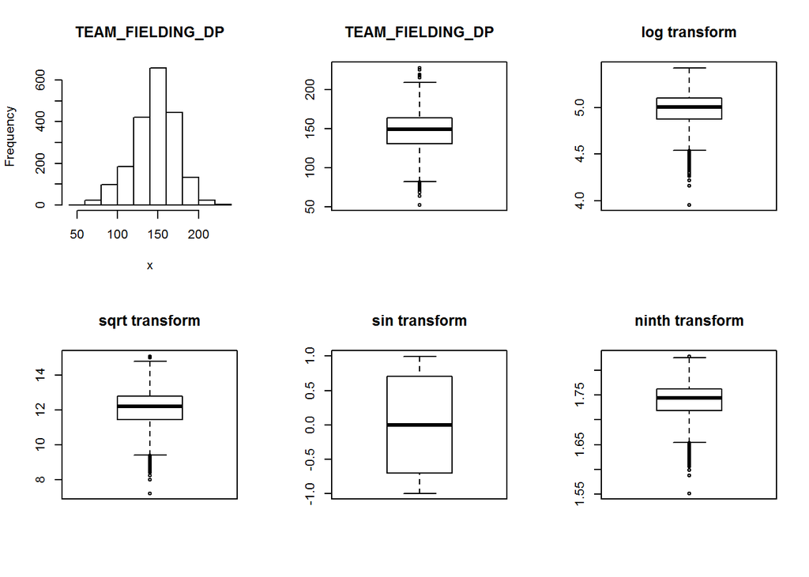

```r
show_charts(moneyball2$TEAM_FIELDING_DP)
```

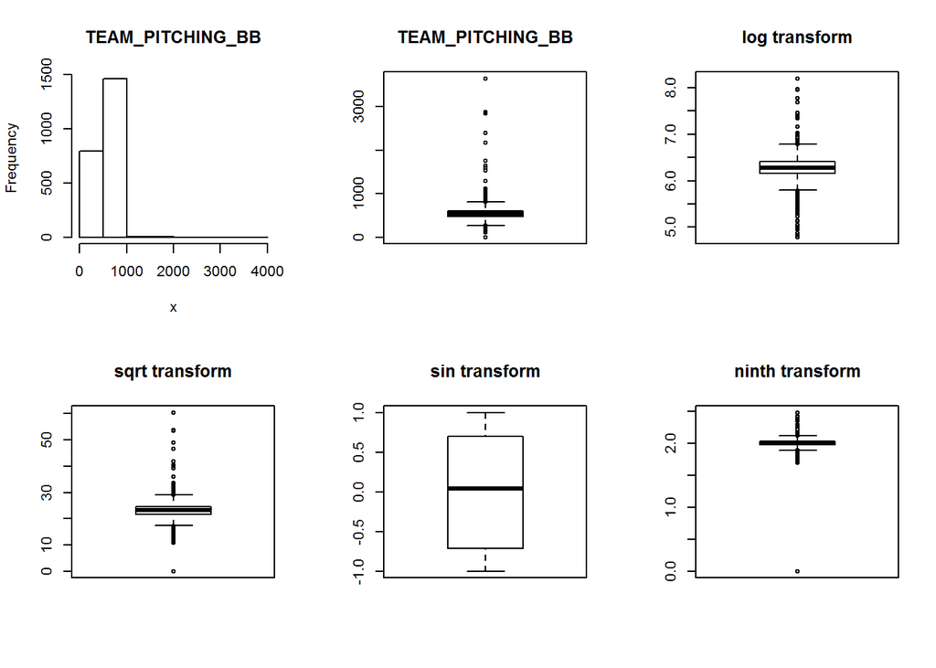

```r
show_charts(moneyball2$TEAM_PITCHING_BB)
```

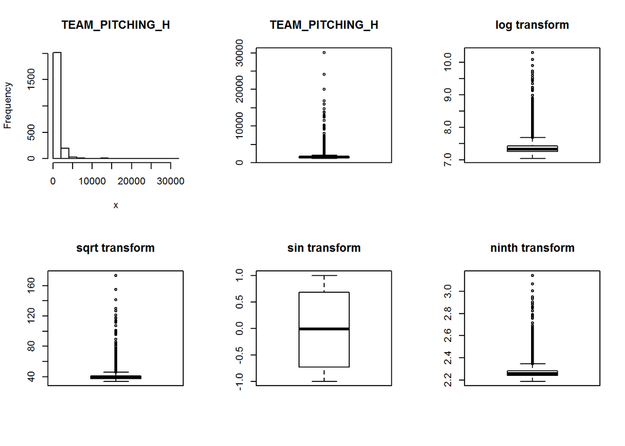

```r
show_charts(moneyball2$TEAM_PITCHING_H)
```

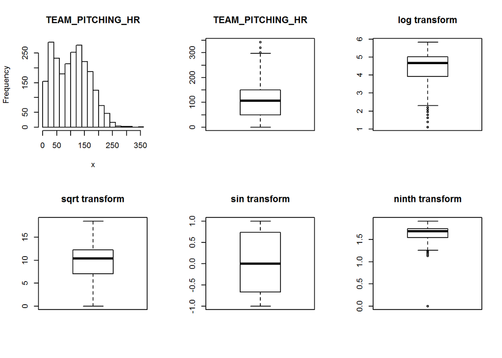

```r
show_charts(moneyball2$TEAM_PITCHING_HR)
```

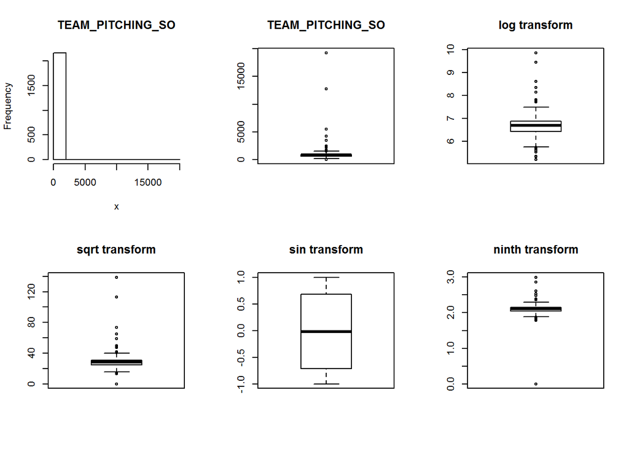

```r
show_charts(moneyball2$TEAM_PITCHING_SO)
```

```r
# par(mfrow=c(2,2))
# hist(moneyball2$TEAM_BATTING_H,main="TEAM_BATTING_H")
# boxplot(moneyball2$TEAM_BATTING_H,main="TEAM_BATTING_H")
#
# hist(moneyball2$TEAM_BATTING_H,main="TEAM_BATTING_H")
# boxplot(sin(moneyball2$TEAM_BATTING_H),main="TEAM_BATTING_H")
#
# boxplot(moneyball2$TEAM_BATTING_H,main="TEAM_BATTING_H")
#
# boxplot(moneyball2$TEAM_BATTING_H,main="TEAM_BATTING_H")
# boxplot(moneyball2$TEAM_BATTING_2B,main="TEAM_BATTING_2B")
# boxplot(moneyball2$TEAM_BATTING_BB,main="TEAM_BATTING_BB")
# boxplot(moneyball2$TEAM_BATTING_SO,main="TEAM_BATTING_SO")
# boxplot(moneyball2$TEAM_BASERUN_SB,main="TEAM_BASERUN_SB")
# boxplot(moneyball2$TEAM_FIELDING_E,main="TEAM_FIELDING_E")
# boxplot(moneyball2$TEAM_FIELDING_DP,main="TEAM_FIELDING_DP")
# boxplot(moneyball2$TEAM_PITCHING_BB,main="TEAM_PITCHING_BB")
# boxplot(moneyball2$TEAM_PITCHING_H,main="TEAM_PITCHING_H")
# boxplot(moneyball2$TEAM_PITCHING_HR,main="TEAM_PITCHING_HR")
# boxplot(moneyball2$TEAM_PITCHING_SO,main="TEAM_PITCHING_SO")
#
```

```r
# par(mfrow=c(3,4))
# boxplot(moneyball2$TEAM_BATTING_H,main="TEAM_BATTING_H")
# boxplot(moneyball2$TEAM_BATTING_2B,main="TEAM_BATTING_2B")
# boxplot(moneyball2$TEAM_BATTING_BB,main="TEAM_BATTING_BB")
# boxplot(moneyball2$TEAM_BATTING_SO,main="TEAM_BATTING_SO")
# boxplot(moneyball2$TEAM_BASERUN_SB,main="TEAM_BASERUN_SB")
# boxplot(moneyball2$TEAM_FIELDING_E,main="TEAM_FIELDING_E")
# boxplot(moneyball2$TEAM_FIELDING_DP,main="TEAM_FIELDING_DP")
# boxplot(moneyball2$TEAM_PITCHING_BB,main="TEAM_PITCHING_BB")
# boxplot(moneyball2$TEAM_PITCHING_H,main="TEAM_PITCHING_H")
# boxplot(moneyball2$TEAM_PITCHING_HR,main="TEAM_PITCHING_HR")
# boxplot(moneyball2$TEAM_PITCHING_SO,main="TEAM_PITCHING_SO")
```

For TEAM_BATTING_H, we can see that there are quite a few outliers, both at the upper and lower end. For this variable we decide to create a new variable that will have the outlier fixed.  
For TEAM_BATTING_2B, we can see that there are quite a few outliers, both at the upper and a single outlier at the lower end. For this variable we decide to create a new variable that will have the outliers fixed.  
For TEAM_BATTING_BB, we can see that there are quite a few outliers, both at the upper and lower end. For this variable we decide to create a new variable that will have the outlier fixed.  
For TEAM_BATTING_SO, we can see that there are no outliers. No further action needed for this variable.  
For TEAM_BASERUN_SB, we can see that there are quite a few outliers at the upper end. For this variable we decide to create a new variable that will have the outlier fixed.  
For TEAM_FIELDING_E, we can see that there are quite a few outliers at the upper end. For this variable we decide to create a new variable that will have the outlier fixed.  
For TEAM_FIELDING_DP, we can see that there are quite a few outliers, both at the upper and lower end. For this variable we decide to create a new variable that will have the outlier fixed.  
For TEAM_PITCHING_BB, we can see that there are quite a few outliers, both at the upper and lower end. For this variable we decide to create a new variable that will have the outlier fixed.  
For TEAM_PITCHING_H, we can see that there are quite a few outliers at the upper end. For this variable we decide to create a new variable that will have the outlier fixed.  
For TEAM_PITCHING_HR, we can see that there only 3 outliers at the upper end. For this variable we decide to create a new variable that will have the outlier fixed.  
For TEAM_PITCHING_SO, we can see that there are quite a few outliers at the upper and a single outlier on the lower end. For this variable we decide to create a new variable that will have the outlier fixed.  
# Data Preparation

Now that we have the preliminary analysis ready, we will go ahead and carry out the necessary transformations to the data.

This will primarily take care of Missing Values, Handle Outliers and create some additional variables.  
## Outliers

For outliers, we will use the capping method. In this method, we will replace all outliers that lie outside the 1.5 times of IQR limits. We will cap it by replacing those observations less than the lower limit with the value of 5th %ile and those that lie above the upper limit with the value of 95th %ile.

Accordingly we create the following new variables while retaining the original variables as is.

TEAM_BATTING_H TEAM_BATTING_2B TEAM_BATTING_BB TEAM_BASERUN_SB TEAM_FIELDING_E TEAM_FIELDING_DP TEAM_PITCHING_BB TEAM_PITCHING_H TEAM_PITCHING_HR TEAM_PITCHING_SO

```r
# function for removing outliers - http://r-statistics.co/Outlier-Treatment-With-R.html

treat_outliers <- function(x) {
qnt <- quantile(x, probs=c(.25, .75), na.rm = T)
caps <- quantile(x, probs=c(.05, .95), na.rm = T)
H <- 1.5 * IQR(x, na.rm = T)
x[x < (qnt[1] - H)] <- caps[1]
x[x > (qnt[2] + H)] <- caps[2]

return(x)
}

TEAM_BATTING_H_NEW <- treat_outliers(moneyball2$TEAM_BATTING_H)
TEAM_BATTING_2B_NEW <- treat_outliers(moneyball2$TEAM_BATTING_2B)
TEAM_BATTING_BB_NEW <- treat_outliers(moneyball2$TEAM_BATTING_BB)
TEAM_BASERUN_SB_NEW <- treat_outliers(moneyball2$TEAM_BASERUN_SB)
TEAM_FIELDING_E_NEW <- treat_outliers(moneyball2$TEAM_FIELDING_E)
TEAM_FIELDING_DP_NEW <- treat_outliers(moneyball2$TEAM_FIELDING_DP)
TEAM_PITCHING_BB_NEW <- treat_outliers(moneyball2$TEAM_PITCHING_BB)
TEAM_PITCHING_H_NEW <- treat_outliers(moneyball2$TEAM_PITCHING_H)
TEAM_PITCHING_HR_NEW <- treat_outliers(moneyball2$TEAM_PITCHING_HR)
TEAM_PITCHING_SO_NEW <- treat_outliers(moneyball2$TEAM_PITCHING_SO)
```

Lets see how the new variables look in boxplots.

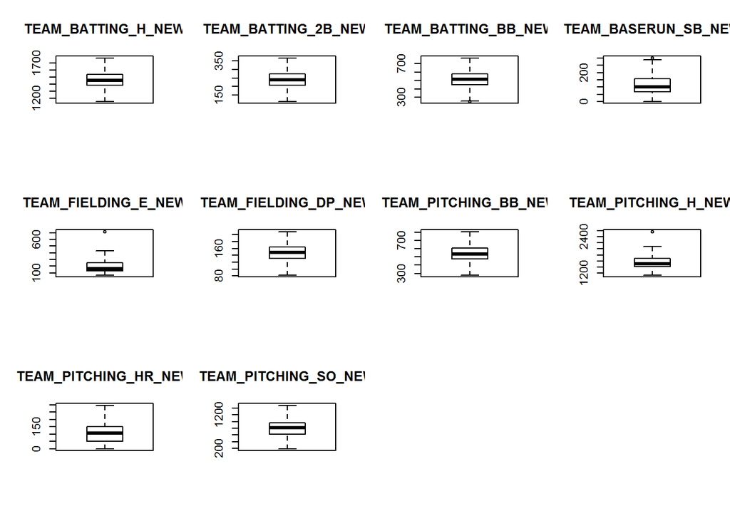

```r
par(mfrow=c(3,4))

boxplot(TEAM_BATTING_H_NEW,main="TEAM_BATTING_H_NEW")
boxplot(TEAM_BATTING_2B_NEW,main="TEAM_BATTING_2B_NEW")
boxplot(TEAM_BATTING_BB_NEW,main="TEAM_BATTING_BB_NEW")
boxplot(TEAM_BASERUN_SB_NEW,main="TEAM_BASERUN_SB_NEW")
boxplot(TEAM_FIELDING_E_NEW,main="TEAM_FIELDING_E_NEW")
boxplot(TEAM_FIELDING_DP_NEW,main="TEAM_FIELDING_DP_NEW")
boxplot(TEAM_PITCHING_BB_NEW,main="TEAM_PITCHING_BB_NEW")
boxplot(TEAM_PITCHING_H_NEW,main="TEAM_PITCHING_H_NEW")
boxplot(TEAM_PITCHING_HR_NEW,main="TEAM_PITCHING_HR_NEW")
boxplot(TEAM_PITCHING_SO_NEW,main="TEAM_PITCHING_SO_NEW")
```